# Introduction to Bayesian GLMs

# R course: Introduction to Bayesian GLMs

[Chris Brown](https://experts.griffith.edu.au/7867-chris-brown)

Welcome to “Introduction to Bayesian GLMs”

# Agenda

```
Intro to Bayesian stats theory

GLM basics and simulating data

Simple GLM with brms package

Checking convergence

Plotting posteriors

Lunch break ~ 30-45 minutes

Under the hood - custom stan code

Prior predictive checks

Random effects in stan code

Random effects with brms

Importance of thinking about variance priors

Non-linear models

Many things you can do with brms

Conclusion
```

# About you

Introductions, what do you want to use Bayesian stats for? Review quiz answers

# Intro to Bayesian stats theory

Probability theory

`P(A)`

`P(A|B)`

`P(A|B)*P(B) = P(B|A)*P(A)`

`P(A,B) = P(A|B)*P(B)`

Now pretend A and B are data and models

Frequentist statistics

P(D|M) = Likelihood

The model can be one parameter value e.g. a mean

We look for the maximuum likelihood.

Hence the idea that there is a fixed ‘truth’ for frequentists

Bayesians interpret it this way:

P(M|D) = P(D|M)*P(M)/P(D)

Explain each of these terms

Hence the idea that the truth is a random variable. [Disease example](https://towardsdatascience.com/intro-to-bayesian-statistics-5056b43d248d)

What is P(D) though?

It’s a normalizing constant. Here’s a simple example of how we can solve for that Assume there are only two models therefore

`P(D) = P(D, M1) + P(D, M2)`

`P(D) = P(D|M1)P(M1) + P(D|M2)P(M2)`

`P(M|D) = P(D|M)*P(M)/[P(D|M1)P(M1) + P(D|M2)P(M2)]`

If there are three models the denominator has three additions and so on.

If the model space is continuous (ie a mean parameter) then we use integration to solve for P(D) Integration for complex multiparameter models can get very nasty… So we use an algorithm to do that. Enter MCMC. We’ll explore this later on. But for know just know that the `P(D)` term has no practical meaning (unlike the other terms) and is just a constant that ensures the LHS sums (or integrates) to 1.

Case study of owls

A = barking owl

B = observed owl

P(owl/obs) = p(obs/there)p( owl is there) / p(obs) P(owl) = 0.005 P(obs/there) = 0.5 P(obs/not there) = 0.01(mistake for boobook) P(obs) = sum prob of all possible ways of seeing an owl = Prob no owl but see it + prob owl and we do see it = `0.995*0.01+ 0.5*0.005`

So overall probability of barking owl given my observation =

```r
0.5*0.005/((0.995*0.01) +(0.5*0.005))
```

Bayesian thinking can be a way of life.

# Case-study fish vs SST

Regression of fish vs SST What do you know about if this is all I told you. What are our priors? Let’s do it as frequentists first, then as bayesians.

# Maximum likelihood GLM

```r
library(brms)
library(dplyr)
library(ggplot2)
library(patchwork)
library(tidyr)
theme_set(theme_classic())
```

## Generate some data

Sorry not using simstudy anymore!

```r
pois_glm_sim <- function(params, x, seed = runif(1, 0, 100000)){
    set.seed(seed)

  with(params,{
    lambda = exp(alpha + beta*x)
    y = rpois(length(x), lambda)
    data.frame(id = 1:length(y), alpha, beta, x, lambda, y)
  })

}
```

```r
set.seed(55)
N <- 50
params <- data.frame(alpha = 0,
               beta = 0.15)
sst_range <- c(8, 25)
sst <- runif(N, sst_range[1], sst_range[2])
sstnorm <- scale(sst)
dat <- pois_glm_sim(params, x = sst, seed = 42)
```

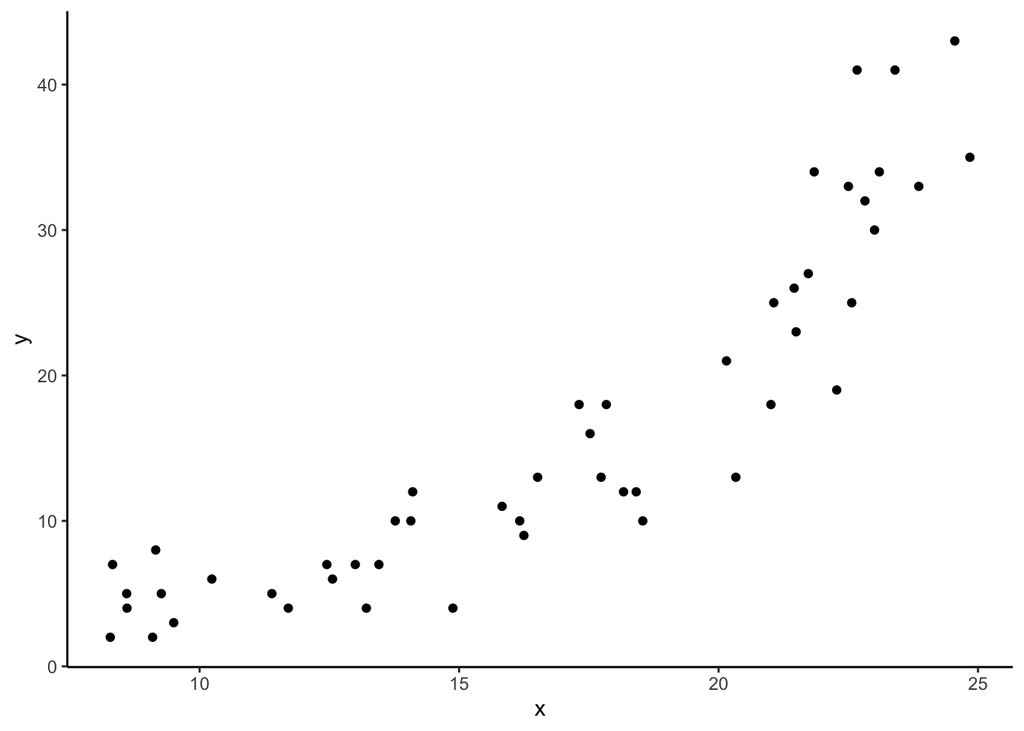

```r
ggplot(dat) +
  aes(x = x, y = y) +
  geom_point()
```

## Fitting a glm

```r
m1 <- glm(y ~ x, family = "poisson",
          data = dat)
pred_m1 <- predict(m1,
                        se = TRUE)
coef(m1)
```

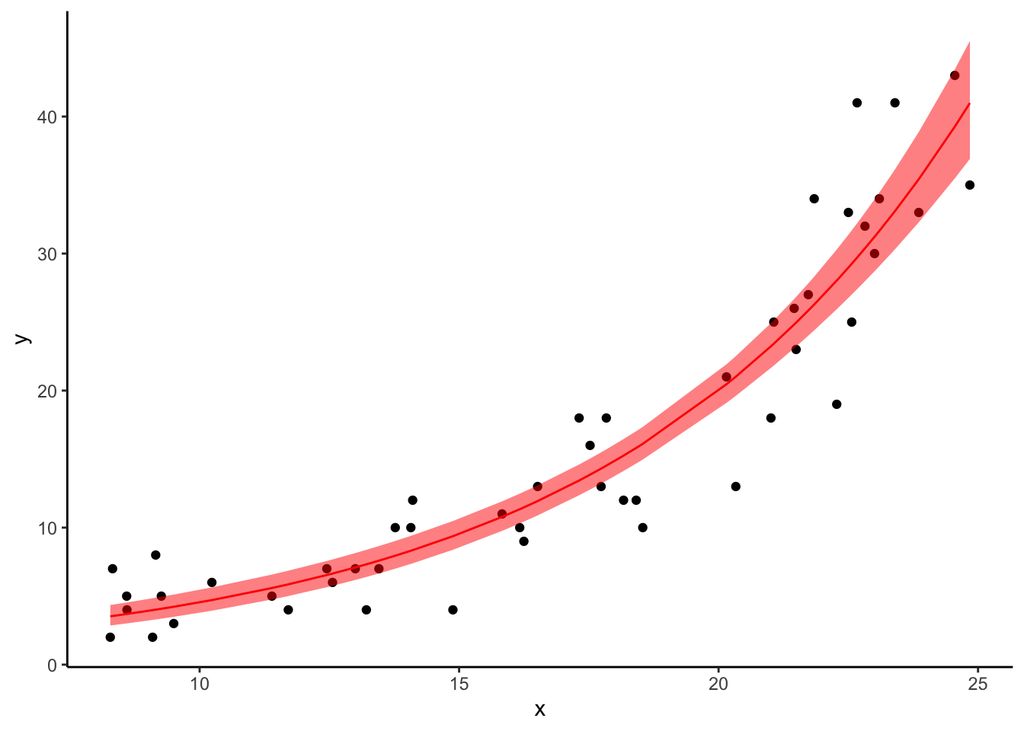

```r
dat$pred_glm <- pred_m1$fit
dat$pred_glm_se <- pred_m1$se.fit

g1 <- ggplot(dat) +
  aes(x = x, y = y) +
  geom_point() +
  geom_line(aes(y = exp(pred_glm)), color = "red") +
  geom_ribbon(aes(ymin = exp(pred_glm - pred_glm_se*1.96),
                  ymax = exp(pred_glm + pred_glm_se*1.96)),
              alpha = 0.5,
              fill = "red")

g1
```

# Bayesian GLM with brms

Try this first with only 1050 samples

```r
options(mc.cores = parallel::detectCores())

b1 <- brm(y ~ x, family = "poisson",
          data = dat,
          chains = 4,
          iter = 2000,
          thin = 1,
          warmup = 1000,
          cores = 4)
# save(b1, file = "models/b1.rda")
```

```r
summary(b1)
```

## Checking convergence

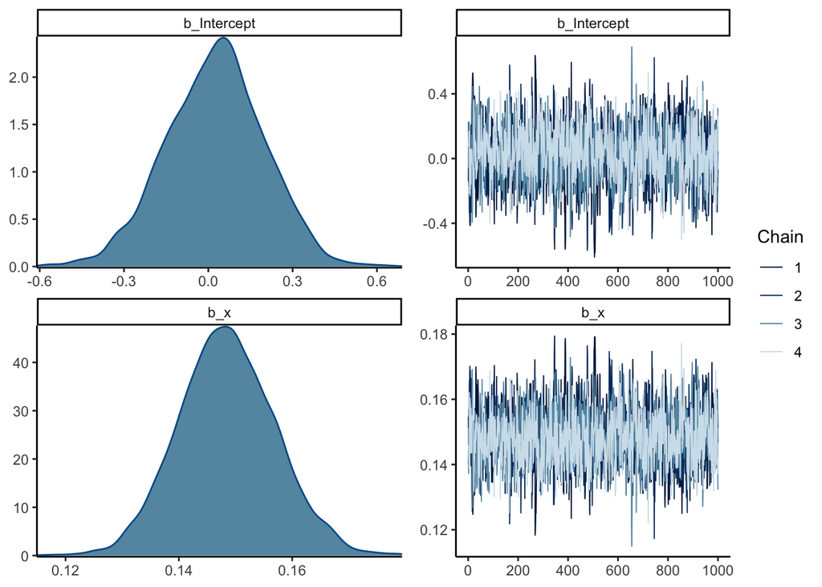

```r
plot(b1)
```

```r
# shinystan::launch_shinystan(b1)
```

#### The folk theorem of statistical computing

“When you have computational problems, often there’s a problem with your model (Yao, Vehtari, and Gelman, 2020)” (or your model is misspecified with respect to the data at hand)

## Plotting predictions

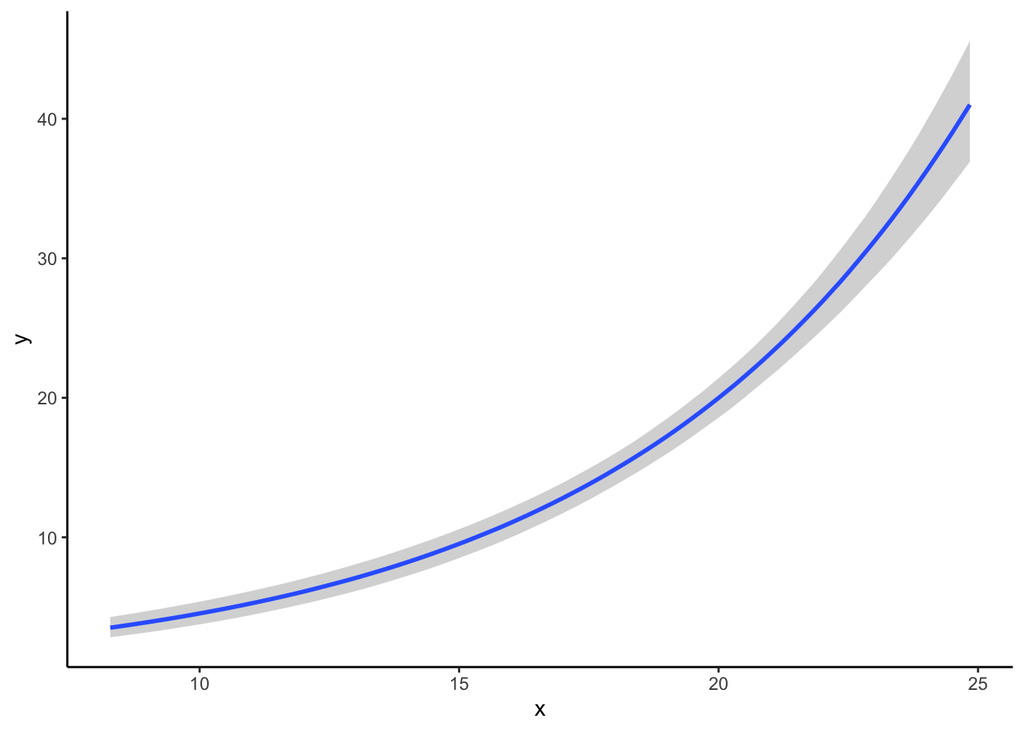

```r
conditional_effects(b1)
```

## Extracting samples

```r
pred_b1 <- posterior_epred(b1)
dim(pred_b1)
```

```r
quantile(pred_b1[,1], c(0.025, 0.5, 0.975))
```

# Comparing to GLM

```r
dat$pred_brm <- colMeans(pred_b1)
dat$pred_brm_lwr <- apply(pred_b1, 2,
                          quantile, probs = 0.025)
dat$pred_brm_upr <- apply(pred_b1, 2,
                          quantile, probs = 0.975)

g2 <- ggplot(dat) +
  aes(x = x, y = y) +
  geom_point() +
  geom_line(aes(y = pred_brm), color = "blue") +
  geom_ribbon(aes(ymin = pred_brm_lwr,
                  ymax = pred_brm_upr),
              alpha = 0.5,
              fill = "blue")
```

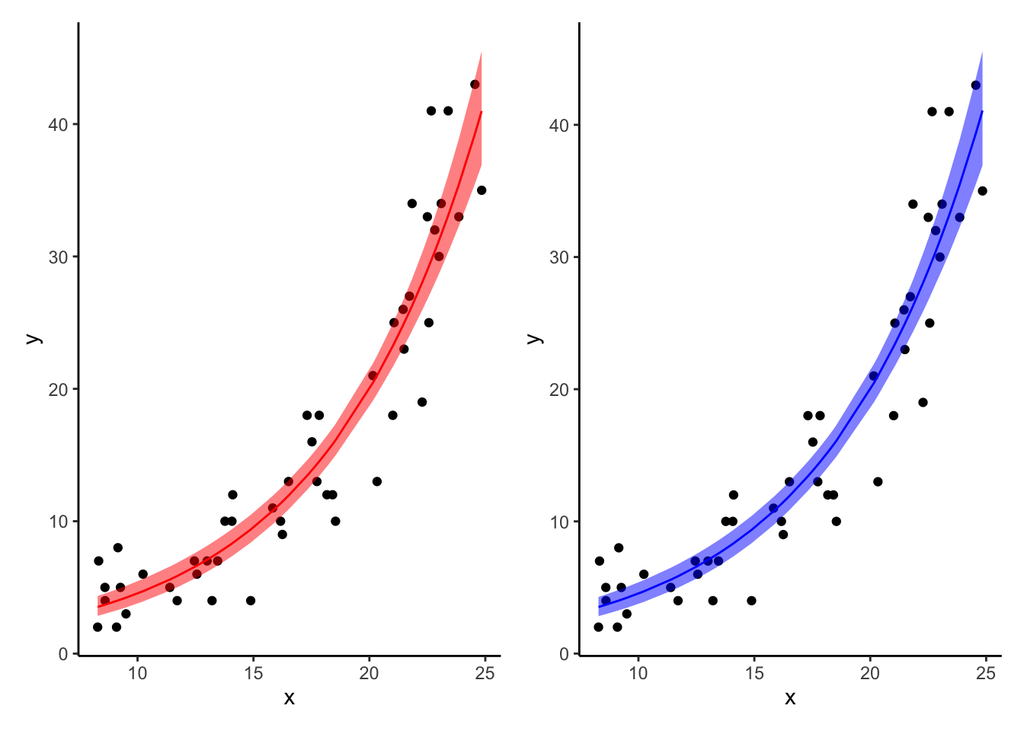

```r
g1 + g2
```

### Predictive intervals

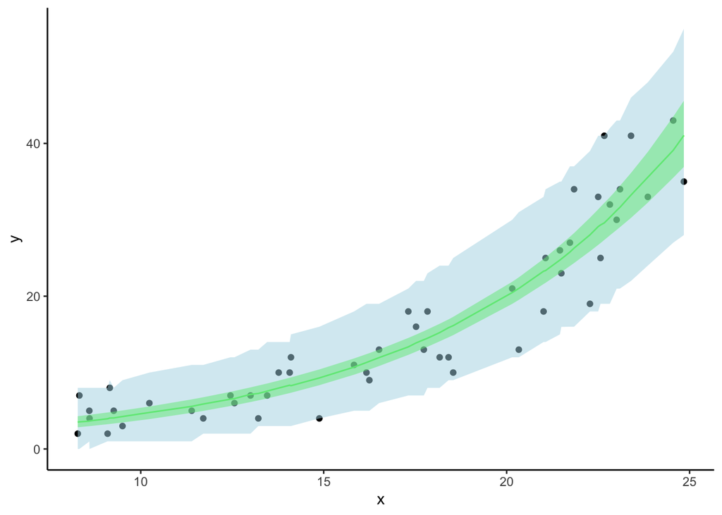

```r
pred_b1 <- posterior_predict(b1)
dat$pred_int <- colMeans(pred_b1)
dat$pred_int_lwr <- apply(pred_b1, 2,
                          quantile, probs = 0.025)
dat$pred_int_upr <- apply(pred_b1, 2,
                          quantile, probs = 0.975)

g3 <- ggplot(dat) +
  aes(x = x, y = y) +
  geom_point() +
  geom_line(aes(y = pred_int), color = "green") +
  geom_ribbon(aes(ymin = pred_brm_lwr,
                  ymax = pred_brm_upr),alpha = 0.5,
              fill = "green") +
  geom_ribbon(aes(ymin = pred_int_lwr,
                  ymax = pred_int_upr),
              alpha = 0.5,
              fill = "lightblue")
g3
```

# Under the hood - stan code

## Simulating data from priors

AKA prior predictive check

```r
library(rstan)
options(mc.cores = parallel::detectCores())

dat_in <- list(N = nrow(dat), y = dat$y,
               x = dat$x)

compiled_model <- stan_model("glm-poisson-sim.stan")

sim_out <- sampling(
  compiled_model, data = dat_in)
```

```r
prior_sims  <- sim_out %>%
  as.data.frame %>%
  select(contains("y_sim"))

summary_tbl <- apply(prior_sims[1:5,], 1, summary)
summary_tbl
```

```r
exp(1 + max(dat$x)*1)
```

Wow!

Try normalize x

```r
dat$xscale <- scale(dat$x)
exp(4+ max(dat$xscale)*2)
```

```r
dat_in <- list(N = nrow(dat), y = dat$y,
               x = as.numeric(dat$xscale))

sim_out <- sampling(
  compiled_model, data = dat_in)

prior_sims  <- sim_out %>%
  as.data.frame %>%
  select(contains("y_sim"))

summary_tbl <- apply(prior_sims[1:5,], 1, summary)
summary_tbl
```

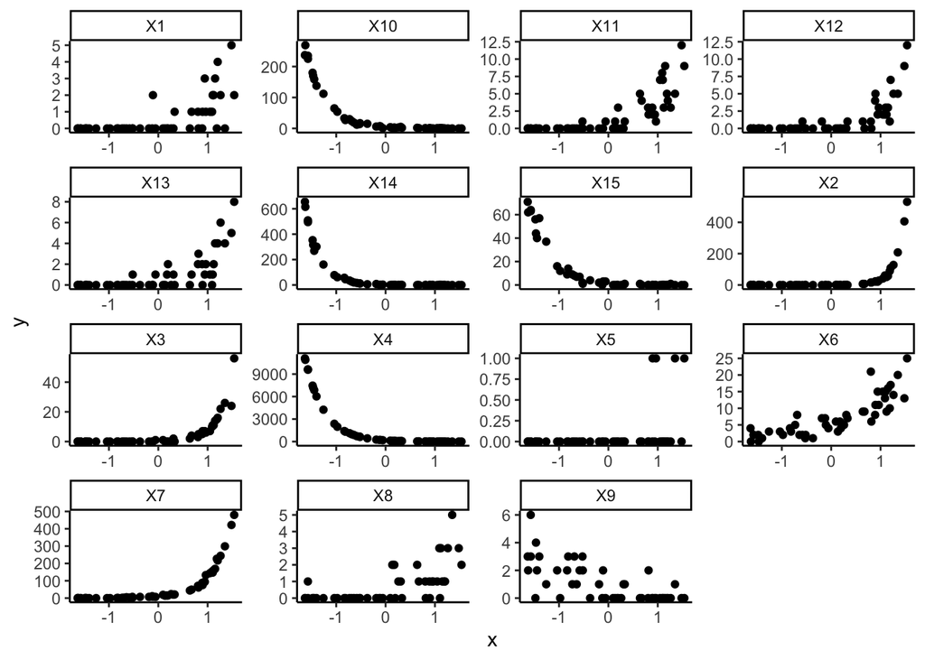

```r
sims_dat <- prior_sims[1:15,] %>%
  t() %>%
  data.frame() %>%
  mutate(x = dat_in$x) %>%
  pivot_longer(-x, names_to = "sim",
               values_to = "y")

ggplot(sims_dat) +
  aes(x = x,y = y) +
  geom_point() +
  facet_wrap(~sim, scale = "free")
```

## Fitting the stan model

```r
dat_in <- list(N = nrow(dat), y = dat$y,
               x = as.numeric(dat$xscale))

fit1 <- stan(file = "glm-poisson.stan",
          data = dat_in,
          iter = 2000,
          warmup = 1000,
          thin = 1,
          chains =  4,
          refresh = 500,
          )
save(fit1, file = "models/fit1.rda")
```

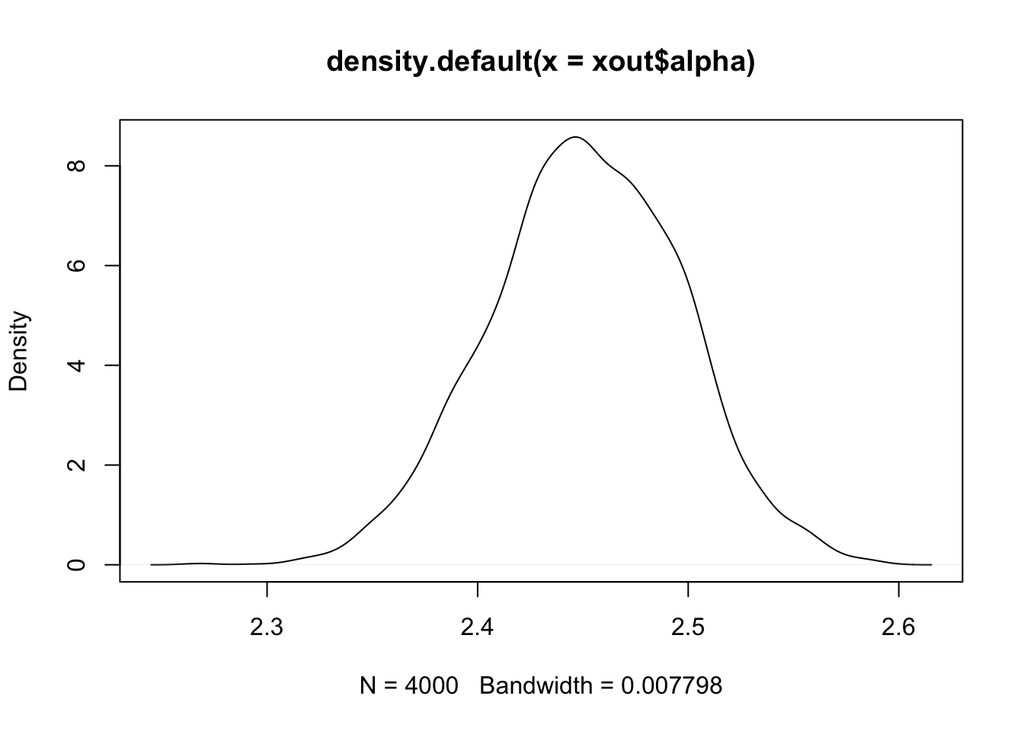

```r
xout <- rstan::extract(fit1)
names(xout)
quantile(xout$alpha, c(0.025, 0.5, 0.975))
quantile(xout$beta, c(0.025, 0.5, 0.975))
plot(density(xout$alpha))
```

```r
fit_summary <- summary(fit1, pars = c("alpha", "beta"),
                       probs = c(0.033, 0.5, 0.67))
fit_summary$summary
```

## Plotting predictions

We can use the `y_sim` or do it this way:

Make a list of dataframes:

```r
listparams <- Map(function(alpha,beta) data.frame(alpha,
                              beta),
       xout$alpha,
       xout$beta)
```

### Predictions using our function

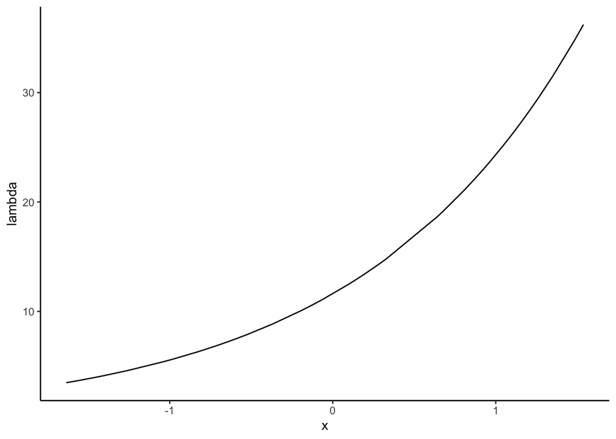

```r
datpred <- lapply(listparams, pois_glm_sim,
                  x = dat$xscale) %>%
  do.call("rbind", .)

datpred <- datpred %>%
  group_by(id) %>%
  summarize(x = mean(x),
            lambda = mean(lambda))

ggplot(datpred) +
  aes(x = x, y = lambda) +
  geom_line()
```

# Random effects models

```r
pois_glmm_sim <- function(params, x,
                          N_per_group,
                          ngrps,
                          seed = runif(1,0, 10000)){

  set.seed(seed)

  #total sample size
  N <- N_per_group * ngrps

  with(params, {
    #random effects
    z <- rnorm(ngrps, 0, sigma)
    Z <- rep(z, each = N_per_group)

    #poisson mean
    lambda <- exp(alpha + beta*x + Z)
    y <- rpois(N, lambda)
    data.frame(id = 1:length(y),
               x, lambda, y,
               #just a trick to convert Z into integer site IDs:
               siteID = as.numeric(factor(Z)))
  })

}
```

```r
#sst values (1 per group/site)
ngrps <- 12
N_per_group <- 5
x <- runif(ngrps, sst_range[1], sst_range[2])
x <- scale(x)
x <- rep(x, each = N_per_group)
```

```r
params <- list(alpha = 2.5,
               beta = 0.75,
               sigma = 0.3)

set.seed(77)
dat2 <- pois_glmm_sim(params, x,
                          N_per_group, ngrps,
                          77)
```

try varying sigma!

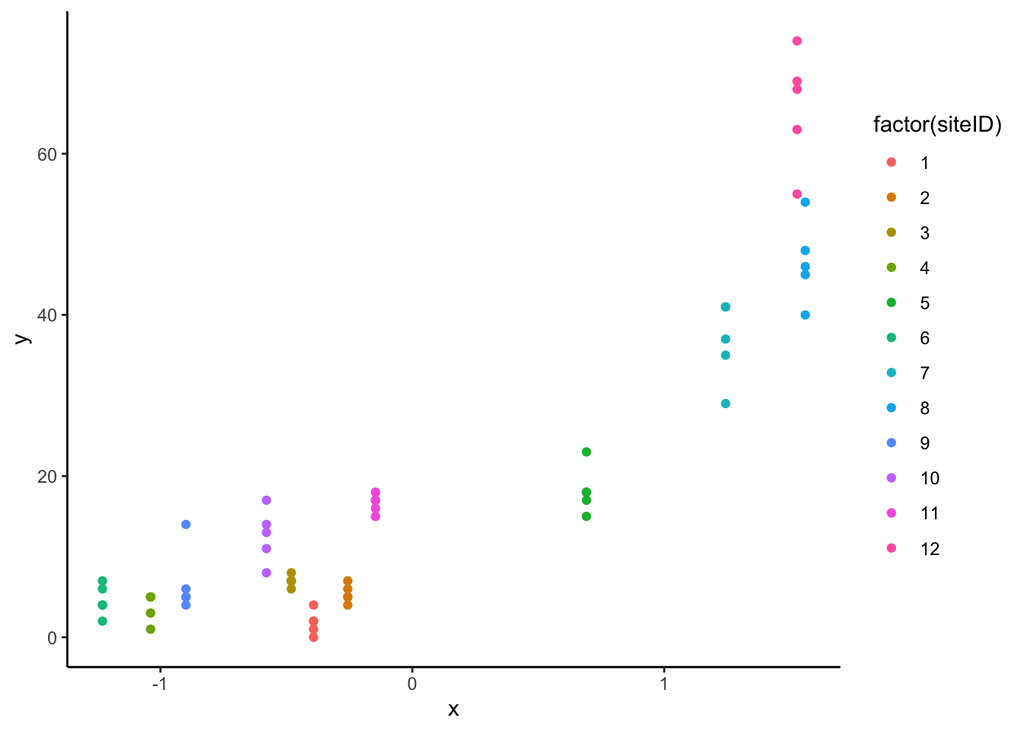

```r
ggplot(dat2) +
  aes(x = x, y = y, color = factor(siteID)) +
  geom_point()
```

## Random effects with stan

```r
dat_in <- list(N = nrow(dat2), y = dat2$y,
               x = dat2$x,
               igroup = dat2$siteID,
               K = length(unique(dat2$siteID)))

fitRE <- stan(file = "glm-poisson-random-effects.stan",
          data = dat_in,
          iter = 2000,
          warmup = 1000,
          thin = 1,
          chains =  4,
          refresh = 500)
save(fitRE, file = "models/fitRE.rda")
```

```r
fit_summary <- summary(fitRE, pars = c("alpha", "beta", "sigma"),
                       probs = c(0.033, 0.5, 0.67))
fit_summary$summary
```

And compare to what we put in:

```r
params
```

## Random effects with brms

```r
b1ME <- brm(y ~ x + (1|siteID), family = "poisson",
          data = dat2,
          chains = 4,
          iter = 2000,
          thin = 1,
          warmup = 1000,
          cores = 4)
save(b1ME, file = "models/b1ME.rda")
```

```r
summary(b1ME)
```

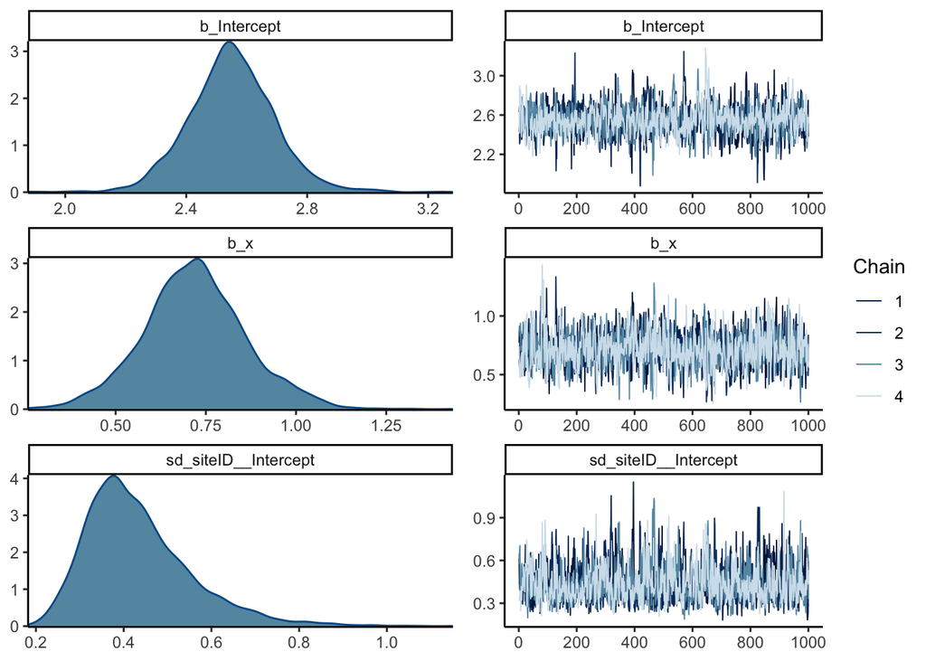

```r
plot(b1ME)
```

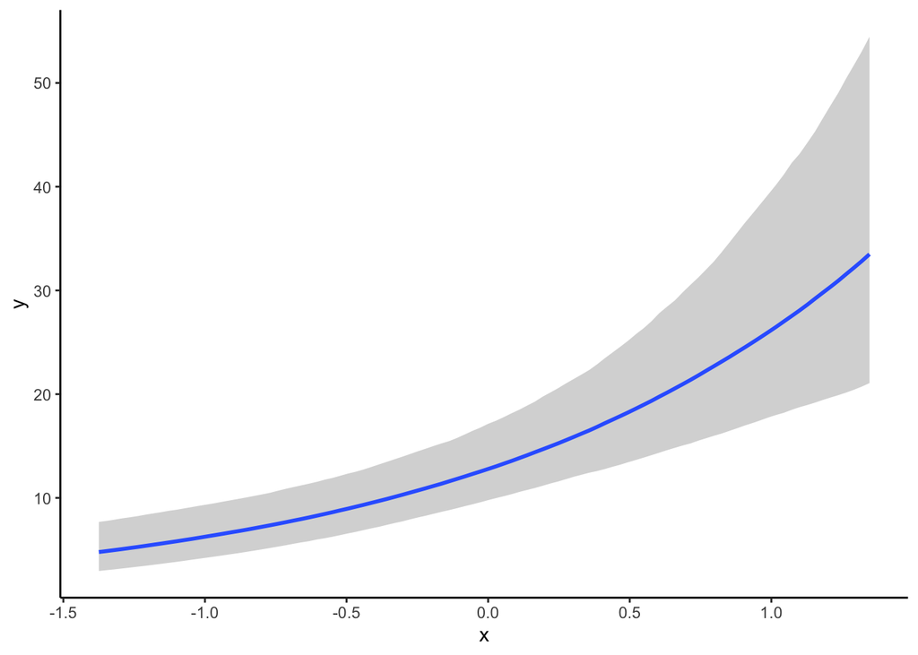

```r
conditional_effects(b1ME)
```

### Look at random effects estimates

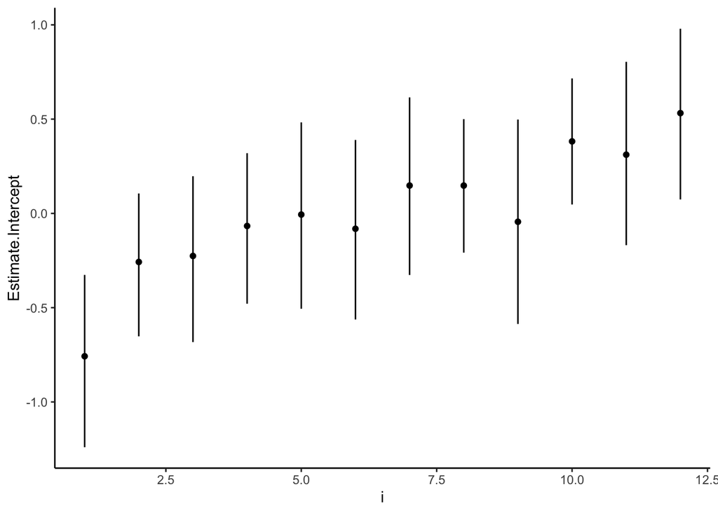

```r
b1z <- ranef(b1ME, groups = "siteID")$siteID %>%
  data.frame() %>%
  mutate(i = 1:n())

ggplot(b1z) +
  aes(x = i) +
  geom_point(aes(y = Estimate.Intercept)) +
  geom_linerange(aes(ymin = Q2.5.Intercept,
                     ymax = Q97.5.Intercept))
```

[Check normality with qqnorm plots](https://www.seascapemodels.org/rstats/2017/10/06/qqplot-non-normal-glm.html)

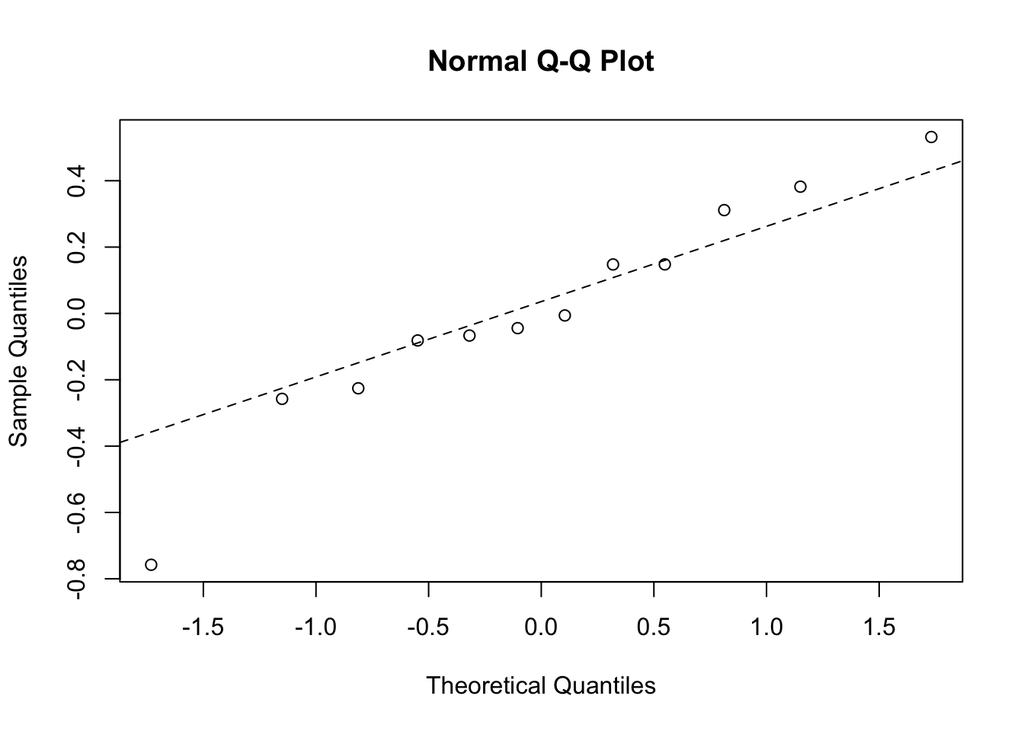

```r
qqnorm(b1z$Estimate.Intercept)
qqline(b1z$Estimate.Intercept, lty = 2)
```

# Importance of variance priors

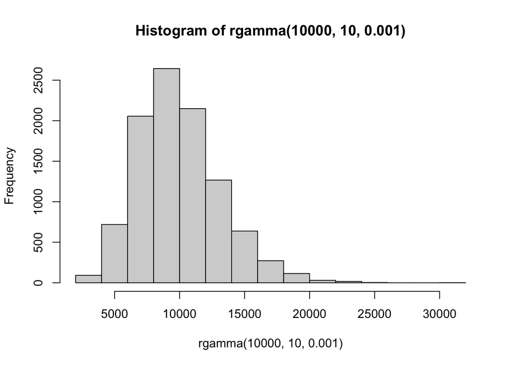

```r
hist(rgamma(10000, 10, 0.001))
```

```r
b1_priors <- get_prior(y ~ x + (1|siteID), family = "poisson",
          data = dat2)
b1_priors
prior_sigma <- set_prior("gamma(10, 0.001)",
                         class = "sd", coef = "Intercept",
                         group = "siteID")
make_stancode(y ~ x + (1|siteID), family = "poisson",
          data = dat2,
          prior = prior_sigma,
          save_model = "dumb-prior.stan")
```

```r
b1ME_gamma001 <- brm(y ~ x + (1|siteID), family = "poisson",
          data = dat2,
          chains = 4,
          iter = 2000,
          thin = 1,
          warmup = 1000,
          cores = 4,
          prior = prior_sigma)
save(b1ME_gamma001, file = "models/b1ME_gamma001.rda")
```

```r
summary(b1ME_gamma001)
```

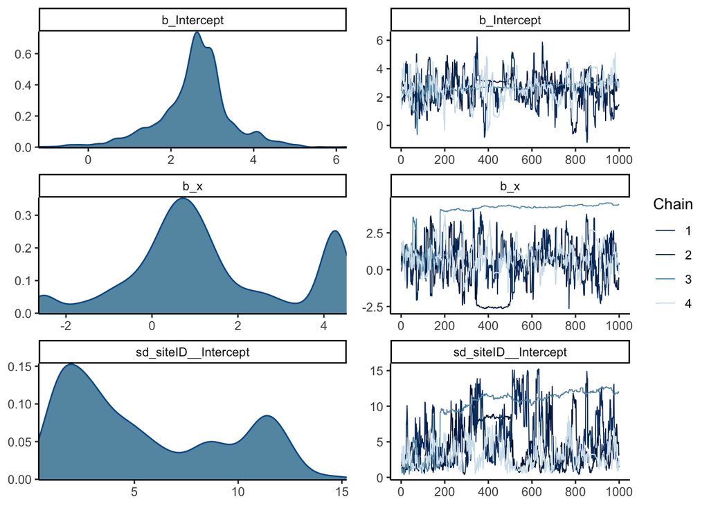

```r
plot(b1ME_gamma001)
```

Notice the chains never converge!

```r
# shinystan::launch_shinystan(b1)
```

# Non-linear models in BRMS

```r
pois_gamm_sim <- function(params, x,
                          N_per_group,
                          ngrps,
                          seed = runif(1,0, 10000)){

  set.seed(seed)

  #total sample size
  N <- N_per_group * ngrps

  with(params, {
    #random effects
    xs <- splines::ns(x,3)
    z <- rnorm(ngrps, 0, sigma)
    Z <- rep(z, each = N_per_group)

    #poisson mean
    lambda <- exp(alpha + beta1*xs[,1] + beta2*xs[,2] + beta3*xs[,3] + Z)
    y <- rpois(N, lambda)
    data.frame(id = 1:length(y),
               x, lambda, y,
               #just a trick to convert Z into integer site IDs:
               siteID = as.numeric(factor(Z)))
  })

}
```

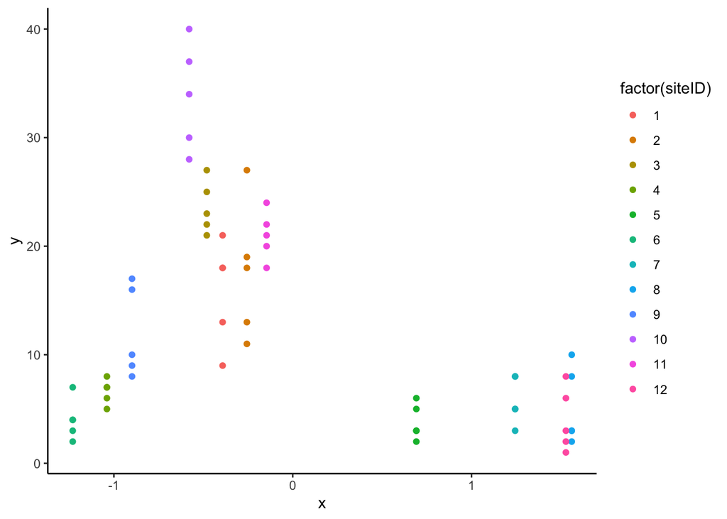

```r
params <- list(alpha = 1,
               beta1 = -1,
               beta2 = 3,
               beta3 = -1,
               sigma = 0.2)

set.seed(77)
dat3 <- pois_gamm_sim(params, x,
                          N_per_group, ngrps,
                          77)

ggplot(dat3) +
  aes(x = x, y = y, color = factor(siteID)) +
  geom_point()
```

```r
b1gam1 <- brm(y ~ s(x) + (1|siteID), family = "poisson",
          data = dat3,
          chains = 4,
          iter = 2000,
          thin = 1,
          warmup = 1000,
          cores = 4)
save(b1gam1, file = "models/b1gam1.rda")
```

```r
summary(b1gam1)
```

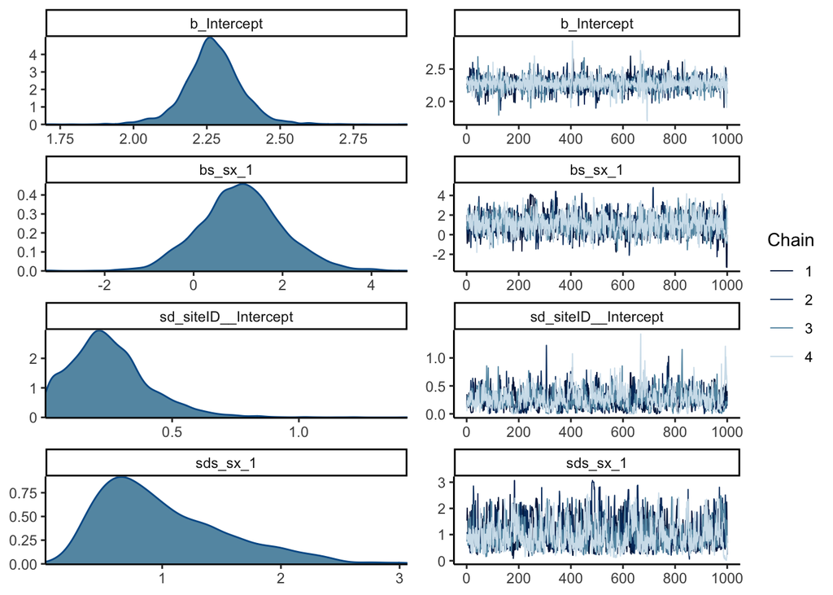

```r
plot(b1gam1)
```

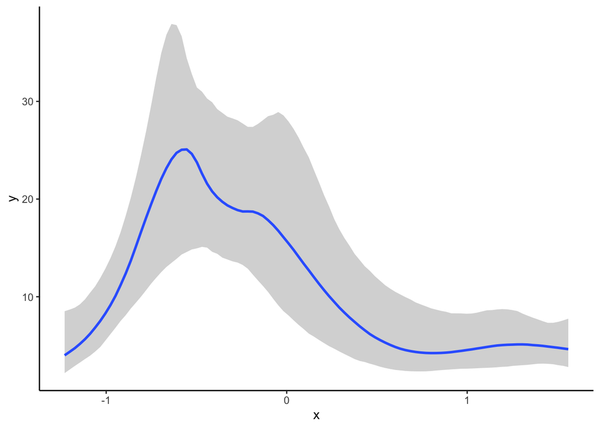

```r
conditional_effects(b1gam1)
```

# Other ideas for things you can do with brms

- Hurdle models (for zero inflated data )
- Simple multivariate models
- Model missing values of fixed effects
- Measurement error models/meta-analyses
- Splines
- Simple state space models (e.g. AR)
- Ordinal/categorical models
- Models where variance/dispersian is regressed against parameters
- Multilevel models (e.g. RE*fixed effect interactions)

And much more!

# Priors for fixed effects

```r
tighter_prior <-
  set_prior("normal(-5,0.1)", class = "b", coef = "sst")
b2 <- brm(y ~ x, family = "poisson",
          data = dat,
          chains = 4,
          iter = 2000,
          thin = 1,
          warmup = 1000,
          cores = 4,
          prior = tighter_prior)
summary(b2)
```

### Comparing to GLM

```r
pred_b2 <- posterior_epred(b2)
dat$pred_brm2 <- colMeans(pred_b2)
dat$pred_brm_lwr2 <- apply(pred_b2, 2,
                          quantile, probs = 0.025)
dat$pred_brm_upr2 <- apply(pred_b2, 2,
                          quantile, probs = 0.975)

ggplot(dat) +
  aes(x = sst, y = fish) +
  geom_point() +
  geom_line(aes(y = pred_brm), color = "blue") +
  geom_ribbon(aes(ymin = pred_brm_lwr,
                  ymax = pred_brm_upr),
              alpha = 0.5,
              fill = "blue") +
  geom_line(aes(y = pred_brm2), color = "green") +
  geom_ribbon(aes(ymin = pred_brm_lwr2,
                  ymax = pred_brm_upr2),
              alpha = 0.5,
              fill = "green")
```

Use predict(b1) if you want the predictive intervals

# Practical things

[Stan userguide online](https://mc-stan.org/users/documentation/)

[Stan and brms forums for Q&A](https://discourse.mc-stan.org/)

My favourite introductory book: Statistical Rethinking

[Bayesian workflow](https://arxiv.org/abs/2011.01808)

If you need to speed up analyses, try the INLA package (but it works differently, not using MCMC)